# Assignmnet 1 : Treatment of DEX and ETOH in HCC70 and MDA231 cell lines

## Introduction

This paper investigates the transcription factors that define the gene expression pattern for basal-like triple negative. Despite RNA-sequencing, the scientists performed different experiments to verify that STAT3 and GR cooperatively defined the gene expression pattern for basal-like triple negative. This dataset from Geo is only a small part, it describes the gene count of two basal-like breast cancer cell lines, HCC70 and MDA231, when treated with dexamethasone or ethanol vehicle control for 4 hours. The purpose of this dataset is to determine which genes are regulated by GR since dexamethasone induces GR.

## Data Exploration

### Basic information about my dataset

**Platform title**:Illumina HiSeq 2000 (Homo sapiens)

**Submission data**:Nov 02 2010

**Last update data**:Mar 27 2019

**Organism**:Mar 27 2019

**Number of GEO datasets that use this technology**:9272

**Number of GEO samples that use this technology**: 159558

```r
#Get the expression Data
#check,names= FALSE  don't want to correct for the data
seq_files =getGEOSuppFiles("GSE152201")
file_name =rownames(seq_files)
file_name
exp_data = read.delim(file_name[1],header=TRUE,check.names = FALSE)
```

#### example of the grouping of my dataset

|  | cell_lines | treatment | replicates |
| --- | --- | --- | --- |
| HCC70_ETOH_4hr_REP1 | HCC70 | ETOH | REP1 |
| HCC70_ETOH_4hr_REP2 | HCC70 | ETOH | REP2 |
| HCC70_ETOH_4hr_REP3 | HCC70 | ETOH | REP3 |
| HCC70_DEX_4hr_REP1 | HCC70 | DEX | REP1 |
| HCC70_DEX_4hr_REP2 | HCC70 | DEX | REP2 |
| HCC70_DEX_4hr_REP3 | HCC70 | DEX | REP3 |

#### Split the variable

The original dataset has some issue with improper ensembl_id. ensembl_id and gene name were together in one variable. I split according to the pattern "_", however, some unimportant data information such as those with 5s_RNA and Y_RNA cause trouble of uneven splitting. I ignore those as those genes are not important and are filtered out mostly in the exp_data_filtered dataset

## Filter low count

```r
count_per_million_HCC=cpm(exp_data[,3:8])
count_per_million_MDA=cpm(exp_data[,9:14])
rownames(count_per_million_HCC)<-exp_data[,"gene_id"]
rownames(count_per_million_MDA)<-exp_data[,"gene_id"]
keep = rowSums(count_per_million_HCC>1 | count_per_million_MDA>1) >= 3
exp_data_filtered =exp_data[keep,]
summarised_gene_count <-sort(table(exp_data_filtered$gene_id),decreasing = TRUE)
summarised_gene_count_unfiltered <-sort(table(exp_data$gene_id),decreasing = TRUE)
kable(summarised_gene_count_unfiltered[which(summarised_gene_count>1)][1:6],format = "html")
kable(summarised_gene_count[which(summarised_gene_count>1)][1:6],format = "html")
dim(exp_data)
low_count_filtered<-nrow(exp_data_filtered)
```

[output not shown]

## Normalization

TMM normalization was applied by grouping treatment using EdgeR package to get trimmed mean. Since my dataset is sort of nested within each cell line, I am wondering if there is better way for normalization. The resulting distribution is unlikely bimodel because I got similar distribution shape when graphing for each cell line alone (data not shown) The bump there is more likely as a result of RNA-seq technology

[figure not shown]

```r
# apply TMM
filtered_data_matrix <- as.matrix(exp_data_filtered[,3:14])
rownames(filtered_data_matrix) <- exp_data_filtered$gene_id
d = DGEList(counts=filtered_data_matrix, group=samples$treatment)
d_TMM = calcNormFactors(d)
normalized_counts <- cpm(d_TMM)
```

[figure not shown]

### PCA representation

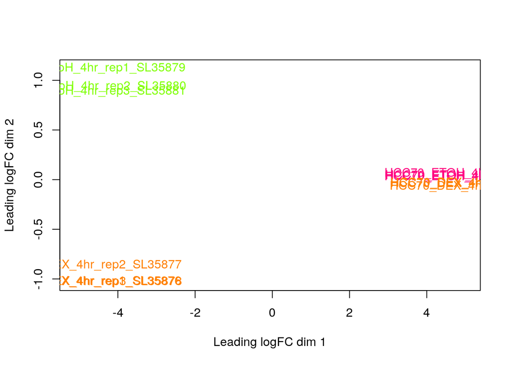

```r
plotMDS(d_TMM,labels = rownames(samples),
        col=sample(cols,replace = FALSE)[factor(samples$treatment)])
```

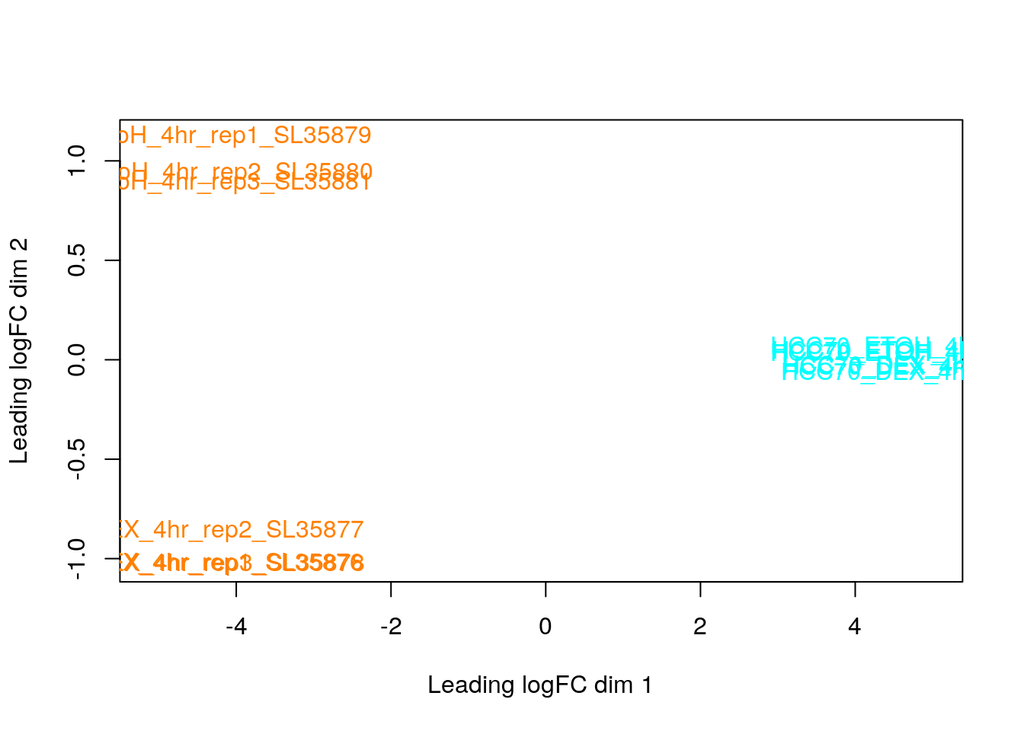

```r
plotMDS(d_TMM,labels = rownames(samples),
        col=sample(cols,replace = FALSE)[factor(samples$cell_lines)])
```

### Dispersion

Small variation as indicated by the graph

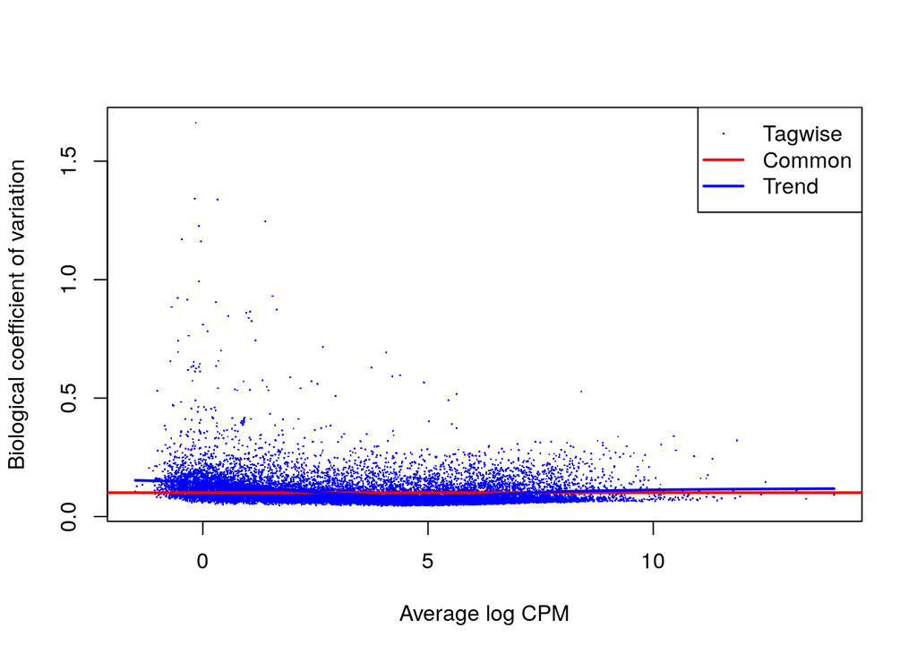

```r
#dispersion: how much your variance deviates for the mean
#low count high variation
model<-model.matrix(~samples$treatment+samples$cell_lines+0)# ?? what is 0
dispersion<-estimateDisp(d_TMM,model)
plotBCV(dispersion,col.tagwise = "blue",col.common = "red")
```

### Identifier mapping

Because the original ensembl id comes with version number and I would lost a lot of information if I use ensembl id with version number to map, therefore, I got rid of version number at the beginning in the splitting variable step

| ensembl_gene_id | hgnc_symbol | HCC70_ETOH_4hr_REP1 | HCC70_ETOH_4hr_REP2 | HCC70_ETOH_4hr_REP3 |
| --- | --- | --- | --- | --- |
| ENSG00000000003 | TSPAN6 | 33.928439 | 30.0955569 | 29.4110395 |
| ENSG00000000419 | DPM1 | 24.616535 | 24.8321685 | 22.9939301 |
| ENSG00000000457 | SCYL3 | 21.140091 | 20.6801375 | 17.5851015 |
| ENSG00000000460 | C1orf112 | 37.322110 | 37.7505863 | 35.7768804 |
| ENSG00000000971 | CFH | 0.165545 | 0.2133806 | 0.2050741 |

| gene_id | gene_name |
| --- | --- |
| ENSG00000005955 | GGNBP2 |
| ENSG00000006114 | SYNRG |
| ENSG00000017373 | SRCIN1 |
| ENSG00000017621 | MAGIX |
| ENSG00000034063 | UHRF1 |
| ENSG00000056661 | PCGF2 |
| ENSG00000068793 | CYFIP1 |
| ENSG00000069712 | KIAA1107 |
| ENSG00000072444 | ASAH2C |
| ENSG00000073009 | IKBKG |

|  | gene_id | gene_name |
| --- | --- | --- |
| 53 | ENSG00000139617 | RP11-298P3.4 |
| 102 | ENSG00000174093 | RP11-1407O15.2 |
| 139 | ENSG00000182109 | RP11-69E11.4 |
| 148 | ENSG00000183405 | RPS7P1 |
| 154 | ENSG00000183900 | RP11-79P5.4 |
| 159 | ENSG00000184779 | RPS17 |

```
## [1] 92.24522
```

I merge the data set and 1480 observations are missing, 317are ribosomal genes but it is not really important for this dataset. The coverage now is 92%

```r
missing_ids_subset <- normalized_counts_merge[   which(is.na(normalized_counts_merge$hgnc_symbol)),]
missing_ids_subset_withids <- merge(old_mapping,missing_ids_subset,by.x=1,by.y=1)
missing_ids_subset_withids <- missing_ids_subset_withids[-3]
colnames(missing_ids_subset_withids)[1:2] <- colnames(normalized_counts_merge)
finalized_normalized_counts <-rbind(normalized_counts_merge[which(!is.na(normalized_counts_merge$hgnc_symbol)),],missing_ids_subset_withids)
```

## Interpretation

*1 What are the control and test conditions of the dataset?

Depending on the cell line, the control is the cell line treated with ethanol and the test condition if the cell line treated with dexamethasone

*2 Why is the dataset of interest to you?

I am interested in this dataset because cancer is a really complicate and heterogeneous. There are diverse sub-clones for each cancer and no cancer cells are alike. It is always interested and therapeutic relevant to find out what are the factors controlling the formation each sub-type.

*3 Were there expression values that were not unique for specific genes?

As indicated in the Filter low count section, there are multiple value mapping to Y_RNA and 5s_rRNA and some NA ( it RNA and rRNA in the table because I split the first variable according to "_" ) NA is likely due to splitting error

*4 Were there expression values that could not be mapped to current HUGO symbols?

Yes, there are -1480 genes that can not mapped, 1480 do not have HGNC symbol. 317 are ribosomal protein which is not really important for this analysis

*5 How did you handle replicates?

None because the paper has not indicated any reason for removing any outliers and the distribution looks normal.

*7 I was able to added back the missing HUGO symbol, the final coverage is around 92%